# Risk Factor Analysis

## Outcome Variable

**Outcome Variable:** whz

## Predictor Variables

**Intervention Variable:** vagbrth

**Adjustment Set:**

- arm
- sex
- W_mage
- meducyrs
- feducyrs
- hhwealth_quart
- W_mhtcm
- W_mwtkg
- W_mbmi
- single
- W_nrooms
- brthmon
- W_parity
- impfloor
- delta_W_mage
- delta_meducyrs
- delta_feducyrs
- delta_hhwealth_quart
- delta_W_mhtcm
- delta_W_mwtkg
- delta_W_mbmi
- delta_single
- delta_W_nrooms
- delta_brthmon
- delta_W_parity
- delta_impfloor

## Stratifying Variables

The analysis was stratified on these variable(s):

- agecat
- studyid
- country

## Data Summary

| agecat | studyid | country | vagbrth | n_cell | n | outcome_variable |
| --- | --- | --- | --- | --- | --- | --- |
| Birth | ki1000108-CMC-V-BCS-2002 | INDIA | 0 | 10 | 86 | whz |
| Birth | ki1000108-CMC-V-BCS-2002 | INDIA | 1 | 76 | 86 | whz |
| Birth | ki1000108-IRC | INDIA | 0 | 66 | 343 | whz |
| Birth | ki1000108-IRC | INDIA | 1 | 277 | 343 | whz |
| Birth | ki1017093b-PROVIDE | BANGLADESH | 0 | 108 | 532 | whz |
| Birth | ki1017093b-PROVIDE | BANGLADESH | 1 | 424 | 532 | whz |
| Birth | ki1017093c-NIH-Crypto | BANGLADESH | 0 | 184 | 465 | whz |
| Birth | ki1017093c-NIH-Crypto | BANGLADESH | 1 | 281 | 465 | whz |
| Birth | ki1119695-PROBIT | BELARUS | 0 | 1593 | 13830 | whz |
| Birth | ki1119695-PROBIT | BELARUS | 1 | 12237 | 13830 | whz |
| Birth | ki1126311-ZVITAMBO | ZIMBABWE | 0 | 1100 | 12814 | whz |
| Birth | ki1126311-ZVITAMBO | ZIMBABWE | 1 | 11714 | 12814 | whz |
| Birth | kiGH5241-JiVitA-3 | BANGLADESH | 0 | 500 | 17985 | whz |
| Birth | kiGH5241-JiVitA-3 | BANGLADESH | 1 | 17485 | 17985 | whz |
| Birth | kiGH5241-JiVitA-4 | BANGLADESH | 0 | 71 | 2395 | whz |
| Birth | kiGH5241-JiVitA-4 | BANGLADESH | 1 | 2324 | 2395 | whz |
| 6 months | ki1000108-CMC-V-BCS-2002 | INDIA | 0 | 25 | 368 | whz |
| 6 months | ki1000108-CMC-V-BCS-2002 | INDIA | 1 | 343 | 368 | whz |
| 6 months | ki1000108-IRC | INDIA | 0 | 68 | 408 | whz |
| 6 months | ki1000108-IRC | INDIA | 1 | 340 | 408 | whz |
| 6 months | ki1017093b-PROVIDE | BANGLADESH | 0 | 139 | 603 | whz |
| 6 months | ki1017093b-PROVIDE | BANGLADESH | 1 | 464 | 603 | whz |
| 6 months | ki1017093c-NIH-Crypto | BANGLADESH | 0 | 187 | 457 | whz |
| 6 months | ki1017093c-NIH-Crypto | BANGLADESH | 1 | 270 | 457 | whz |
| 6 months | ki1066203-TanzaniaChild2 | TANZANIA, UNITED REPUBLIC OF | 0 | 189 | 2004 | whz |
| 6 months | ki1066203-TanzaniaChild2 | TANZANIA, UNITED REPUBLIC OF | 1 | 1815 | 2004 | whz |
| 6 months | ki1119695-PROBIT | BELARUS | 0 | 1798 | 15758 | whz |
| 6 months | ki1119695-PROBIT | BELARUS | 1 | 13960 | 15758 | whz |
| 6 months | ki1126311-ZVITAMBO | ZIMBABWE | 0 | 721 | 8437 | whz |
| 6 months | ki1126311-ZVITAMBO | ZIMBABWE | 1 | 7716 | 8437 | whz |
| 6 months | kiGH5241-JiVitA-3 | BANGLADESH | 0 | 1075 | 16705 | whz |
| 6 months | kiGH5241-JiVitA-3 | BANGLADESH | 1 | 15630 | 16705 | whz |
| 6 months | kiGH5241-JiVitA-4 | BANGLADESH | 0 | 337 | 4056 | whz |
| 6 months | kiGH5241-JiVitA-4 | BANGLADESH | 1 | 3719 | 4056 | whz |
| 24 months | ki1000108-CMC-V-BCS-2002 | INDIA | 0 | 25 | 372 | whz |
| 24 months | ki1000108-CMC-V-BCS-2002 | INDIA | 1 | 347 | 372 | whz |
| 24 months | ki1000108-IRC | INDIA | 0 | 69 | 409 | whz |
| 24 months | ki1000108-IRC | INDIA | 1 | 340 | 409 | whz |
| 24 months | ki1017093b-PROVIDE | BANGLADESH | 0 | 137 | 579 | whz |
| 24 months | ki1017093b-PROVIDE | BANGLADESH | 1 | 442 | 579 | whz |
| 24 months | ki1017093c-NIH-Crypto | BANGLADESH | 0 | 99 | 260 | whz |
| 24 months | ki1017093c-NIH-Crypto | BANGLADESH | 1 | 161 | 260 | whz |
| 24 months | ki1066203-TanzaniaChild2 | TANZANIA, UNITED REPUBLIC OF | 0 | 2 | 6 | whz |
| 24 months | ki1066203-TanzaniaChild2 | TANZANIA, UNITED REPUBLIC OF | 1 | 4 | 6 | whz |
| 24 months | ki1119695-PROBIT | BELARUS | 0 | 463 | 3972 | whz |
| 24 months | ki1119695-PROBIT | BELARUS | 1 | 3509 | 3972 | whz |
| 24 months | ki1126311-ZVITAMBO | ZIMBABWE | 0 | 28 | 426 | whz |
| 24 months | ki1126311-ZVITAMBO | ZIMBABWE | 1 | 398 | 426 | whz |
| 24 months | kiGH5241-JiVitA-3 | BANGLADESH | 0 | 475 | 8555 | whz |
| 24 months | kiGH5241-JiVitA-3 | BANGLADESH | 1 | 8080 | 8555 | whz |
| 24 months | kiGH5241-JiVitA-4 | BANGLADESH | 0 | 323 | 4008 | whz |
| 24 months | kiGH5241-JiVitA-4 | BANGLADESH | 1 | 3685 | 4008 | whz |

The following strata were considered:

- agecat: 24 months, studyid: ki1000108-CMC-V-BCS-2002, country: INDIA
- agecat: 24 months, studyid: ki1000108-IRC, country: INDIA
- agecat: 24 months, studyid: ki1017093b-PROVIDE, country: BANGLADESH
- agecat: 24 months, studyid: ki1017093c-NIH-Crypto, country: BANGLADESH
- agecat: 24 months, studyid: ki1066203-TanzaniaChild2, country: TANZANIA, UNITED REPUBLIC OF
- agecat: 24 months, studyid: ki1119695-PROBIT, country: BELARUS
- agecat: 24 months, studyid: ki1126311-ZVITAMBO, country: ZIMBABWE
- agecat: 24 months, studyid: kiGH5241-JiVitA-3, country: BANGLADESH
- agecat: 24 months, studyid: kiGH5241-JiVitA-4, country: BANGLADESH
- agecat: 6 months, studyid: ki1000108-CMC-V-BCS-2002, country: INDIA
- agecat: 6 months, studyid: ki1000108-IRC, country: INDIA
- agecat: 6 months, studyid: ki1017093b-PROVIDE, country: BANGLADESH
- agecat: 6 months, studyid: ki1017093c-NIH-Crypto, country: BANGLADESH
- agecat: 6 months, studyid: ki1066203-TanzaniaChild2, country: TANZANIA, UNITED REPUBLIC OF
- agecat: 6 months, studyid: ki1119695-PROBIT, country: BELARUS
- agecat: 6 months, studyid: ki1126311-ZVITAMBO, country: ZIMBABWE
- agecat: 6 months, studyid: kiGH5241-JiVitA-3, country: BANGLADESH
- agecat: 6 months, studyid: kiGH5241-JiVitA-4, country: BANGLADESH
- agecat: Birth, studyid: ki1000108-CMC-V-BCS-2002, country: INDIA
- agecat: Birth, studyid: ki1000108-IRC, country: INDIA
- agecat: Birth, studyid: ki1017093b-PROVIDE, country: BANGLADESH
- agecat: Birth, studyid: ki1017093c-NIH-Crypto, country: BANGLADESH
- agecat: Birth, studyid: ki1119695-PROBIT, country: BELARUS
- agecat: Birth, studyid: ki1126311-ZVITAMBO, country: ZIMBABWE
- agecat: Birth, studyid: kiGH5241-JiVitA-3, country: BANGLADESH
- agecat: Birth, studyid: kiGH5241-JiVitA-4, country: BANGLADESH

### Dropped Strata

Some strata were dropped due to rare outcomes:

- agecat: 24 months, studyid: ki1066203-TanzaniaChild2, country: TANZANIA, UNITED REPUBLIC OF

## Methods Detail

We’re interested in the causal parameters $E[Y_a]$ for all values of $a \in \mathcal{A}$. These parameters represent the mean outcome if, possibly contrary to fact, we intervened to set all units to have $A=a$. Under the randomization and positivity assumptions, these are identified by the statistical parameters $\psi_a=E_W[E_{Y|A,W}(Y|A=a,W)]$. In addition, we’re interested in the mean of $Y$, $E[Y]$ under no intervention (the observed mean). We will estimate these parameters by using SuperLearner to fit the relevant likelihood factors – $E_{Y|A,W}(Y|A=a,W)$ and $p(A=a|W)$, and then updating our likelihood fit using a joint TMLE.

For unadjusted analyses ($W=\{\}$), initial likelihoods were estimated using Lrnr_glm to estimate the simple $E(Y|A)$ and Lrnr_mean to estimate $p(A)$. For adjusted analyses, a small library containing Lrnr_glmnet, Lrnr_xgboost, and Lrnr_mean was used.

Having estimated these parameters, we will then use the delta method to estimate relative risks and attributable risks relative to a prespecified baseline level of $A$.

# Results Detail

## Results Plots

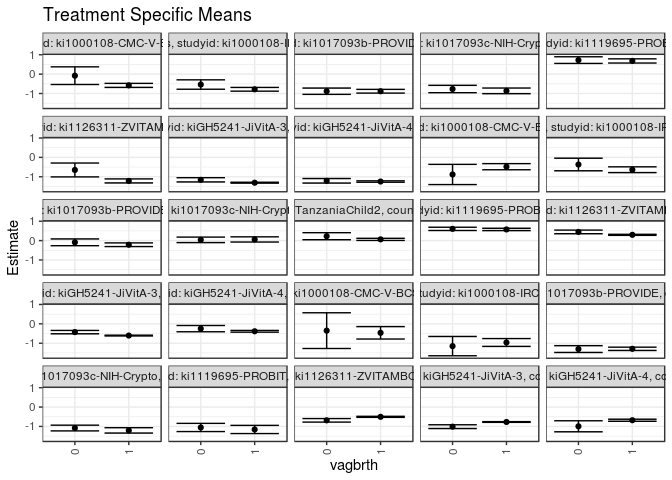

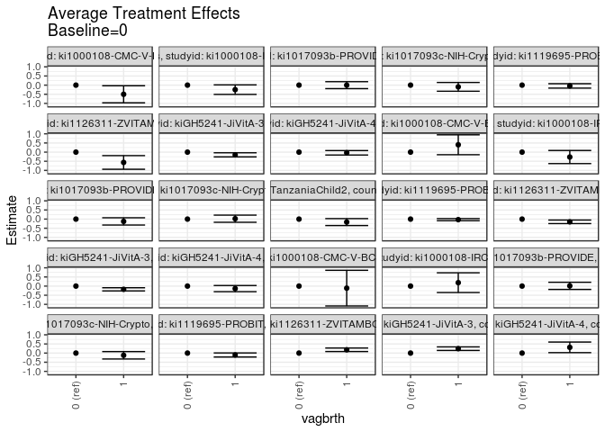

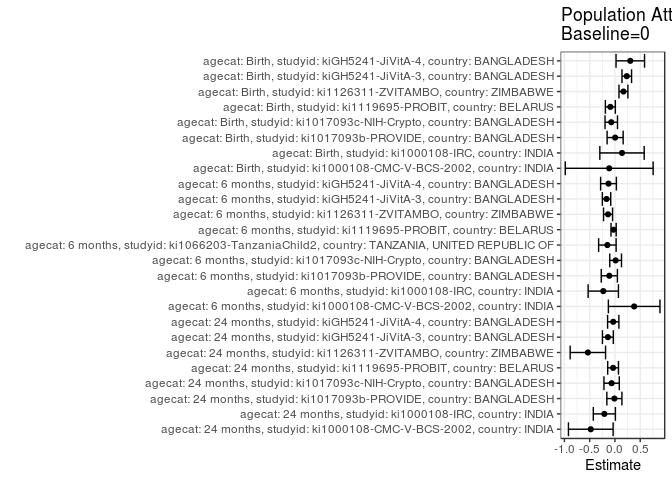

## Results Table

### Parameter: TSM

| agecat | studyid | country | intervention_level | baseline_level | estimate | ci_lower | ci_upper |
| --- | --- | --- | --- | --- | --- | --- | --- |
| Birth | ki1000108-CMC-V-BCS-2002 | INDIA | 0 | NA | -0.3508738 | -1.2732454 | 0.5714978 |
| Birth | ki1000108-CMC-V-BCS-2002 | INDIA | 1 | NA | -0.4630659 | -0.7836709 | -0.1424608 |
| Birth | ki1000108-IRC | INDIA | 0 | NA | -1.1500807 | -1.6479341 | -0.6522273 |
| Birth | ki1000108-IRC | INDIA | 1 | NA | -0.9623376 | -1.1643648 | -0.7603103 |
| Birth | ki1017093b-PROVIDE | BANGLADESH | 0 | NA | -1.3017772 | -1.4775675 | -1.1259869 |
| Birth | ki1017093b-PROVIDE | BANGLADESH | 1 | NA | -1.2889930 | -1.3744672 | -1.2035187 |
| Birth | ki1017093c-NIH-Crypto | BANGLADESH | 0 | NA | -1.0816577 | -1.2303822 | -0.9329333 |
| Birth | ki1017093c-NIH-Crypto | BANGLADESH | 1 | NA | -1.2030927 | -1.3414548 | -1.0647307 |
| Birth | ki1119695-PROBIT | BELARUS | 0 | NA | -1.0536911 | -1.2653017 | -0.8420806 |
| Birth | ki1119695-PROBIT | BELARUS | 1 | NA | -1.1565676 | -1.3684939 | -0.9446413 |
| Birth | ki1126311-ZVITAMBO | ZIMBABWE | 0 | NA | -0.6846003 | -0.7764337 | -0.5927668 |
| Birth | ki1126311-ZVITAMBO | ZIMBABWE | 1 | NA | -0.5041904 | -0.5313306 | -0.4770501 |
| Birth | kiGH5241-JiVitA-3 | BANGLADESH | 0 | NA | -1.0111408 | -1.1081785 | -0.9141030 |
| Birth | kiGH5241-JiVitA-3 | BANGLADESH | 1 | NA | -0.7701317 | -0.7893859 | -0.7508774 |
| Birth | kiGH5241-JiVitA-4 | BANGLADESH | 0 | NA | -0.9922013 | -1.2767432 | -0.7076594 |
| Birth | kiGH5241-JiVitA-4 | BANGLADESH | 1 | NA | -0.6791501 | -0.7325075 | -0.6257927 |
| 6 months | ki1000108-CMC-V-BCS-2002 | INDIA | 0 | NA | -0.8825433 | -1.4039891 | -0.3610976 |
| 6 months | ki1000108-CMC-V-BCS-2002 | INDIA | 1 | NA | -0.4808321 | -0.6387149 | -0.3229494 |
| 6 months | ki1000108-IRC | INDIA | 0 | NA | -0.3678550 | -0.6934731 | -0.0422369 |
| 6 months | ki1000108-IRC | INDIA | 1 | NA | -0.6368234 | -0.7859858 | -0.4876611 |
| 6 months | ki1017093b-PROVIDE | BANGLADESH | 0 | NA | -0.0877047 | -0.2617863 | 0.0863769 |
| 6 months | ki1017093b-PROVIDE | BANGLADESH | 1 | NA | -0.2132917 | -0.3076572 | -0.1189261 |
| 6 months | ki1017093c-NIH-Crypto | BANGLADESH | 0 | NA | 0.0385193 | -0.1034095 | 0.1804480 |
| 6 months | ki1017093c-NIH-Crypto | BANGLADESH | 1 | NA | 0.0604984 | -0.0734156 | 0.1944123 |
| 6 months | ki1066203-TanzaniaChild2 | TANZANIA, UNITED REPUBLIC OF | 0 | NA | 0.2268972 | 0.0449357 | 0.4088588 |
| 6 months | ki1066203-TanzaniaChild2 | TANZANIA, UNITED REPUBLIC OF | 1 | NA | 0.0646719 | 0.0093858 | 0.1199580 |
| 6 months | ki1119695-PROBIT | BELARUS | 0 | NA | 0.6063056 | 0.5222056 | 0.6904057 |
| 6 months | ki1119695-PROBIT | BELARUS | 1 | NA | 0.5766744 | 0.5169636 | 0.6363851 |
| 6 months | ki1126311-ZVITAMBO | ZIMBABWE | 0 | NA | 0.4481638 | 0.3549253 | 0.5414024 |
| 6 months | ki1126311-ZVITAMBO | ZIMBABWE | 1 | NA | 0.2985809 | 0.2716501 | 0.3255117 |
| 6 months | kiGH5241-JiVitA-3 | BANGLADESH | 0 | NA | -0.4269390 | -0.5136422 | -0.3402358 |
| 6 months | kiGH5241-JiVitA-3 | BANGLADESH | 1 | NA | -0.6045280 | -0.6243078 | -0.5847482 |
| 6 months | kiGH5241-JiVitA-4 | BANGLADESH | 0 | NA | -0.2478488 | -0.4094502 | -0.0862474 |
| 6 months | kiGH5241-JiVitA-4 | BANGLADESH | 1 | NA | -0.3844856 | -0.4296498 | -0.3393214 |
| 24 months | ki1000108-CMC-V-BCS-2002 | INDIA | 0 | NA | -0.0787828 | -0.5347867 | 0.3772211 |
| 24 months | ki1000108-CMC-V-BCS-2002 | INDIA | 1 | NA | -0.5800233 | -0.6846818 | -0.4753648 |
| 24 months | ki1000108-IRC | INDIA | 0 | NA | -0.5359780 | -0.7782918 | -0.2936643 |
| 24 months | ki1000108-IRC | INDIA | 1 | NA | -0.7830013 | -0.8790949 | -0.6869078 |
| 24 months | ki1017093b-PROVIDE | BANGLADESH | 0 | NA | -0.8814649 | -1.0447730 | -0.7181568 |
| 24 months | ki1017093b-PROVIDE | BANGLADESH | 1 | NA | -0.8826081 | -0.9784196 | -0.7867966 |
| 24 months | ki1017093c-NIH-Crypto | BANGLADESH | 0 | NA | -0.7682530 | -0.9585077 | -0.5779983 |
| 24 months | ki1017093c-NIH-Crypto | BANGLADESH | 1 | NA | -0.8629079 | -1.0078823 | -0.7179336 |
| 24 months | ki1119695-PROBIT | BELARUS | 0 | NA | 0.7246594 | 0.5526239 | 0.8966948 |
| 24 months | ki1119695-PROBIT | BELARUS | 1 | NA | 0.6824180 | 0.5738543 | 0.7909818 |
| 24 months | ki1126311-ZVITAMBO | ZIMBABWE | 0 | NA | -0.6504635 | -1.0081518 | -0.2927752 |
| 24 months | ki1126311-ZVITAMBO | ZIMBABWE | 1 | NA | -1.2152663 | -1.3192494 | -1.1112833 |
| 24 months | kiGH5241-JiVitA-3 | BANGLADESH | 0 | NA | -1.1581881 | -1.2679099 | -1.0484664 |
| 24 months | kiGH5241-JiVitA-3 | BANGLADESH | 1 | NA | -1.3081401 | -1.3320552 | -1.2842250 |
| 24 months | kiGH5241-JiVitA-4 | BANGLADESH | 0 | NA | -1.2092441 | -1.3258936 | -1.0925945 |
| 24 months | kiGH5241-JiVitA-4 | BANGLADESH | 1 | NA | -1.2461121 | -1.2817651 | -1.2104592 |

### Parameter: E(Y)

| agecat | studyid | country | intervention_level | baseline_level | estimate | ci_lower | ci_upper |
| --- | --- | --- | --- | --- | --- | --- | --- |
| Birth | ki1000108-CMC-V-BCS-2002 | INDIA | NA | NA | -0.4648256 | -0.7643210 | -0.1653302 |
| Birth | ki1000108-IRC | INDIA | NA | NA | -1.0105831 | -1.1973019 | -0.8238643 |
| Birth | ki1017093b-PROVIDE | BANGLADESH | NA | NA | -1.2984586 | -1.3752758 | -1.2216415 |
| Birth | ki1017093c-NIH-Crypto | BANGLADESH | NA | NA | -1.1549785 | -1.2577390 | -1.0522180 |
| Birth | ki1119695-PROBIT | BELARUS | NA | NA | -1.1448633 | -1.3544229 | -0.9353037 |
| Birth | ki1126311-ZVITAMBO | ZIMBABWE | NA | NA | -0.5168886 | -0.5428625 | -0.4909146 |
| Birth | kiGH5241-JiVitA-3 | BANGLADESH | NA | NA | -0.7774729 | -0.7964631 | -0.7584827 |
| Birth | kiGH5241-JiVitA-4 | BANGLADESH | NA | NA | -0.6890188 | -0.7414800 | -0.6365575 |
| 6 months | ki1000108-CMC-V-BCS-2002 | INDIA | NA | NA | -0.5026766 | -0.6536848 | -0.3516685 |
| 6 months | ki1000108-IRC | INDIA | NA | NA | -0.5989297 | -0.7344491 | -0.4634104 |
| 6 months | ki1017093b-PROVIDE | BANGLADESH | NA | NA | -0.1990907 | -0.2817968 | -0.1163845 |
| 6 months | ki1017093c-NIH-Crypto | BANGLADESH | NA | NA | 0.0515536 | -0.0469240 | 0.1500313 |
| 6 months | ki1066203-TanzaniaChild2 | TANZANIA, UNITED REPUBLIC OF | NA | NA | 0.0769382 | 0.0241090 | 0.1297674 |
| 6 months | ki1119695-PROBIT | BELARUS | NA | NA | 0.5792439 | 0.5193388 | 0.6391490 |
| 6 months | ki1126311-ZVITAMBO | ZIMBABWE | NA | NA | 0.3116179 | 0.2858347 | 0.3374010 |
| 6 months | kiGH5241-JiVitA-3 | BANGLADESH | NA | NA | -0.5935070 | -0.6130727 | -0.5739413 |
| 6 months | kiGH5241-JiVitA-4 | BANGLADESH | NA | NA | -0.3758037 | -0.4184544 | -0.3331531 |
| 24 months | ki1000108-CMC-V-BCS-2002 | INDIA | NA | NA | -0.5571505 | -0.6585247 | -0.4557763 |
| 24 months | ki1000108-IRC | INDIA | NA | NA | -0.7458150 | -0.8368180 | -0.6548120 |
| 24 months | ki1017093b-PROVIDE | BANGLADESH | NA | NA | -0.8928670 | -0.9755153 | -0.8102187 |
| 24 months | ki1017093c-NIH-Crypto | BANGLADESH | NA | NA | -0.8343077 | -0.9482310 | -0.7203844 |
| 24 months | ki1119695-PROBIT | BELARUS | NA | NA | 0.6874295 | 0.5756922 | 0.7991668 |
| 24 months | ki1126311-ZVITAMBO | ZIMBABWE | NA | NA | -1.1864319 | -1.2865891 | -1.0862748 |
| 24 months | kiGH5241-JiVitA-3 | BANGLADESH | NA | NA | -1.2983928 | -1.3216893 | -1.2750962 |
| 24 months | kiGH5241-JiVitA-4 | BANGLADESH | NA | NA | -1.2433658 | -1.2774681 | -1.2092634 |

### Parameter: ATE

| agecat | studyid | country | intervention_level | baseline_level | estimate | ci_lower | ci_upper |
| --- | --- | --- | --- | --- | --- | --- | --- |
| Birth | ki1000108-CMC-V-BCS-2002 | INDIA | 0 | 0 | 0.0000000 | 0.0000000 | 0.0000000 |
| Birth | ki1000108-CMC-V-BCS-2002 | INDIA | 1 | 0 | -0.1121921 | -1.0877080 | 0.8633238 |
| Birth | ki1000108-IRC | INDIA | 0 | 0 | 0.0000000 | 0.0000000 | 0.0000000 |
| Birth | ki1000108-IRC | INDIA | 1 | 0 | 0.1877431 | -0.3513184 | 0.7268047 |
| Birth | ki1017093b-PROVIDE | BANGLADESH | 0 | 0 | 0.0000000 | 0.0000000 | 0.0000000 |
| Birth | ki1017093b-PROVIDE | BANGLADESH | 1 | 0 | 0.0127842 | -0.1829167 | 0.2084852 |
| Birth | ki1017093c-NIH-Crypto | BANGLADESH | 0 | 0 | 0.0000000 | 0.0000000 | 0.0000000 |
| Birth | ki1017093c-NIH-Crypto | BANGLADESH | 1 | 0 | -0.1214350 | -0.3241359 | 0.0812659 |
| Birth | ki1119695-PROBIT | BELARUS | 0 | 0 | 0.0000000 | 0.0000000 | 0.0000000 |
| Birth | ki1119695-PROBIT | BELARUS | 1 | 0 | -0.1028765 | -0.2139696 | 0.0082167 |
| Birth | ki1126311-ZVITAMBO | ZIMBABWE | 0 | 0 | 0.0000000 | 0.0000000 | 0.0000000 |
| Birth | ki1126311-ZVITAMBO | ZIMBABWE | 1 | 0 | 0.1804099 | 0.0847086 | 0.2761113 |
| Birth | kiGH5241-JiVitA-3 | BANGLADESH | 0 | 0 | 0.0000000 | 0.0000000 | 0.0000000 |
| Birth | kiGH5241-JiVitA-3 | BANGLADESH | 1 | 0 | 0.2410091 | 0.1432450 | 0.3387733 |
| Birth | kiGH5241-JiVitA-4 | BANGLADESH | 0 | 0 | 0.0000000 | 0.0000000 | 0.0000000 |
| Birth | kiGH5241-JiVitA-4 | BANGLADESH | 1 | 0 | 0.3130512 | 0.0227960 | 0.6033064 |
| 6 months | ki1000108-CMC-V-BCS-2002 | INDIA | 0 | 0 | 0.0000000 | 0.0000000 | 0.0000000 |
| 6 months | ki1000108-CMC-V-BCS-2002 | INDIA | 1 | 0 | 0.4017112 | -0.1426119 | 0.9460342 |
| 6 months | ki1000108-IRC | INDIA | 0 | 0 | 0.0000000 | 0.0000000 | 0.0000000 |
| 6 months | ki1000108-IRC | INDIA | 1 | 0 | -0.2689685 | -0.6272728 | 0.0893359 |
| 6 months | ki1017093b-PROVIDE | BANGLADESH | 0 | 0 | 0.0000000 | 0.0000000 | 0.0000000 |
| 6 months | ki1017093b-PROVIDE | BANGLADESH | 1 | 0 | -0.1255869 | -0.3243721 | 0.0731982 |
| 6 months | ki1017093c-NIH-Crypto | BANGLADESH | 0 | 0 | 0.0000000 | 0.0000000 | 0.0000000 |
| 6 months | ki1017093c-NIH-Crypto | BANGLADESH | 1 | 0 | 0.0219791 | -0.1731748 | 0.2171330 |
| 6 months | ki1066203-TanzaniaChild2 | TANZANIA, UNITED REPUBLIC OF | 0 | 0 | 0.0000000 | 0.0000000 | 0.0000000 |
| 6 months | ki1066203-TanzaniaChild2 | TANZANIA, UNITED REPUBLIC OF | 1 | 0 | -0.1622253 | -0.3523963 | 0.0279457 |
| 6 months | ki1119695-PROBIT | BELARUS | 0 | 0 | 0.0000000 | 0.0000000 | 0.0000000 |
| 6 months | ki1119695-PROBIT | BELARUS | 1 | 0 | -0.0296313 | -0.0868737 | 0.0276111 |
| 6 months | ki1126311-ZVITAMBO | ZIMBABWE | 0 | 0 | 0.0000000 | 0.0000000 | 0.0000000 |
| 6 months | ki1126311-ZVITAMBO | ZIMBABWE | 1 | 0 | -0.1495829 | -0.2464879 | -0.0526780 |
| 6 months | kiGH5241-JiVitA-3 | BANGLADESH | 0 | 0 | 0.0000000 | 0.0000000 | 0.0000000 |
| 6 months | kiGH5241-JiVitA-3 | BANGLADESH | 1 | 0 | -0.1775890 | -0.2642768 | -0.0909012 |
| 6 months | kiGH5241-JiVitA-4 | BANGLADESH | 0 | 0 | 0.0000000 | 0.0000000 | 0.0000000 |
| 6 months | kiGH5241-JiVitA-4 | BANGLADESH | 1 | 0 | -0.1366368 | -0.3054524 | 0.0321788 |
| 24 months | ki1000108-CMC-V-BCS-2002 | INDIA | 0 | 0 | 0.0000000 | 0.0000000 | 0.0000000 |
| 24 months | ki1000108-CMC-V-BCS-2002 | INDIA | 1 | 0 | -0.5012405 | -0.9692667 | -0.0332143 |
| 24 months | ki1000108-IRC | INDIA | 0 | 0 | 0.0000000 | 0.0000000 | 0.0000000 |
| 24 months | ki1000108-IRC | INDIA | 1 | 0 | -0.2470233 | -0.5088132 | 0.0147666 |
| 24 months | ki1017093b-PROVIDE | BANGLADESH | 0 | 0 | 0.0000000 | 0.0000000 | 0.0000000 |
| 24 months | ki1017093b-PROVIDE | BANGLADESH | 1 | 0 | -0.0011432 | -0.1907502 | 0.1884638 |
| 24 months | ki1017093c-NIH-Crypto | BANGLADESH | 0 | 0 | 0.0000000 | 0.0000000 | 0.0000000 |
| 24 months | ki1017093c-NIH-Crypto | BANGLADESH | 1 | 0 | -0.0946549 | -0.3345876 | 0.1452778 |
| 24 months | ki1119695-PROBIT | BELARUS | 0 | 0 | 0.0000000 | 0.0000000 | 0.0000000 |
| 24 months | ki1119695-PROBIT | BELARUS | 1 | 0 | -0.0422413 | -0.1626516 | 0.0781690 |
| 24 months | ki1126311-ZVITAMBO | ZIMBABWE | 0 | 0 | 0.0000000 | 0.0000000 | 0.0000000 |
| 24 months | ki1126311-ZVITAMBO | ZIMBABWE | 1 | 0 | -0.5648029 | -0.9376208 | -0.1919849 |
| 24 months | kiGH5241-JiVitA-3 | BANGLADESH | 0 | 0 | 0.0000000 | 0.0000000 | 0.0000000 |
| 24 months | kiGH5241-JiVitA-3 | BANGLADESH | 1 | 0 | -0.1499520 | -0.2621391 | -0.0377649 |
| 24 months | kiGH5241-JiVitA-4 | BANGLADESH | 0 | 0 | 0.0000000 | 0.0000000 | 0.0000000 |
| 24 months | kiGH5241-JiVitA-4 | BANGLADESH | 1 | 0 | -0.0368681 | -0.1580902 | 0.0843541 |

### Parameter: PAR

| agecat | studyid | country | intervention_level | baseline_level | estimate | ci_lower | ci_upper |
| --- | --- | --- | --- | --- | --- | --- | --- |
| Birth | ki1000108-CMC-V-BCS-2002 | INDIA | 0 | NA | -0.1139518 | -0.9829878 | 0.7550842 |
| Birth | ki1000108-IRC | INDIA | 0 | NA | 0.1394976 | -0.2991910 | 0.5781863 |
| Birth | ki1017093b-PROVIDE | BANGLADESH | 0 | NA | 0.0033185 | -0.1554760 | 0.1621130 |
| Birth | ki1017093c-NIH-Crypto | BANGLADESH | 0 | NA | -0.0733208 | -0.1966113 | 0.0499698 |
| Birth | ki1119695-PROBIT | BELARUS | 0 | NA | -0.0911722 | -0.1897880 | 0.0074436 |
| Birth | ki1126311-ZVITAMBO | ZIMBABWE | 0 | NA | 0.1677117 | 0.0797334 | 0.2556901 |
| Birth | kiGH5241-JiVitA-3 | BANGLADESH | 0 | NA | 0.2336679 | 0.1388582 | 0.3284776 |
| Birth | kiGH5241-JiVitA-4 | BANGLADESH | 0 | NA | 0.3031825 | 0.0212542 | 0.5851108 |
| 6 months | ki1000108-CMC-V-BCS-2002 | INDIA | 0 | NA | 0.3798667 | -0.1303808 | 0.8901142 |
| 6 months | ki1000108-IRC | INDIA | 0 | NA | -0.2310748 | -0.5307499 | 0.0686004 |
| 6 months | ki1017093b-PROVIDE | BANGLADESH | 0 | NA | -0.1113860 | -0.2710463 | 0.0482744 |
| 6 months | ki1017093c-NIH-Crypto | BANGLADESH | 0 | NA | 0.0130343 | -0.1029885 | 0.1290572 |
| 6 months | ki1066203-TanzaniaChild2 | TANZANIA, UNITED REPUBLIC OF | 0 | NA | -0.1499590 | -0.3231192 | 0.0232012 |
| 6 months | ki1119695-PROBIT | BELARUS | 0 | NA | -0.0270618 | -0.0780690 | 0.0239455 |
| 6 months | ki1126311-ZVITAMBO | ZIMBABWE | 0 | NA | -0.1365459 | -0.2258863 | -0.0472056 |
| 6 months | kiGH5241-JiVitA-3 | BANGLADESH | 0 | NA | -0.1665680 | -0.2493108 | -0.0838252 |
| 6 months | kiGH5241-JiVitA-4 | BANGLADESH | 0 | NA | -0.1279550 | -0.2839031 | 0.0279932 |
| 24 months | ki1000108-CMC-V-BCS-2002 | INDIA | 0 | NA | -0.4783677 | -0.9201837 | -0.0365517 |
| 24 months | ki1000108-IRC | INDIA | 0 | NA | -0.2098370 | -0.4282923 | 0.0086184 |
| 24 months | ki1017093b-PROVIDE | BANGLADESH | 0 | NA | -0.0114021 | -0.1605237 | 0.1377195 |
| 24 months | ki1017093c-NIH-Crypto | BANGLADESH | 0 | NA | -0.0660547 | -0.2175215 | 0.0854121 |
| 24 months | ki1119695-PROBIT | BELARUS | 0 | NA | -0.0372299 | -0.1439280 | 0.0694683 |
| 24 months | ki1126311-ZVITAMBO | ZIMBABWE | 0 | NA | -0.5359684 | -0.8860110 | -0.1859259 |
| 24 months | kiGH5241-JiVitA-3 | BANGLADESH | 0 | NA | -0.1402046 | -0.2477619 | -0.0326473 |
| 24 months | kiGH5241-JiVitA-4 | BANGLADESH | 0 | NA | -0.0341217 | -0.1458522 | 0.0776087 |